# Homework 2

IS 6489

Himanshi Sharma

September 7, 2017

## Getting started

Loading the Bikeshare date.

```r
day <- read_csv("~/day.csv")
View(day)
```

## Question 1

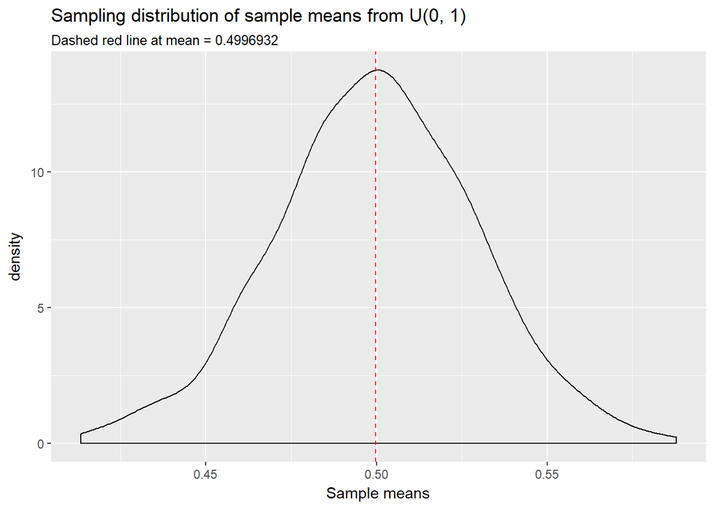

```r
set.seed(917)
data.frame(means = replicate(1000, mean(runif(100)))) %>%
  ggplot(aes(means)) +
  geom_density() +
  labs(title = "Sampling distribution of sample means from U(0, 1)",
       subtitle = "Dashed red line at mean = 0.4996932",
       x = "Sample means") +
  geom_vline(xintercept = .4996932, col = "red", lty = 2)
```

## Question 2

```r
set.seed(917)
means1 = data.frame(ms = replicate(1000, mean(runif(100))))
round(sd(means1$ms),2)
```

```
## [1] 0.03
```

## Question 3

The plot created in Question 1 have a normal bell shaped curve centered at the mean of the sampling distribution 0.4996932 which is approximately equal to the population mean (for U(0,1)) of 0.5. This is the result of Central Limit Theorem, which says that if we were to calculate repeated mean of a distribution such as uniform, binomial, exponential etc then the sampling distribution of the mean will approximate to normal distribution with the mean converging to the population mean given significant n(number of observation). In other words, Central Limit Theorem ensures that irrespective of the underlying population the sampling distribution of mean will be normal with mean = $\mu$ and standard deviation = $\sqrt{\sigma^2/n}$.

## Question 4

```r
day %>%
  group_by(season) %>%
  summarize(SE = round(sd(cnt)/sqrt(length(cnt)),2))
```

```
## # A tibble: 4 x 2
##   season     SE
##    <int>  <dbl>
## 1      1 104.06
## 2      2 125.03
## 3      3 106.47
## 4      4 127.39
```

## Question 5

```r
season1 = subset(day, season == 1)
season2 = subset(day, season == 2)
season3 = subset(day, season == 3)
season4 = subset(day, season == 4)
boot_mean <- NULL
set.seed(123)
for( i in 1:1000){
  boot_sample <- sample(season1$cnt, replace = T)
  boot_mean[i] <- mean(boot_sample)
}
round(sd(boot_mean),2)
```

```
## [1] 106.53
```

```r
set.seed(123)
boot_mean <- NULL
for( i in 1:1000){
  boot_sample <- sample(season2$cnt, replace = T)
  boot_mean[i] <- mean(boot_sample)
}
round(sd(boot_mean),2)
```

```
## [1] 123.48
```

```r
set.seed(123)
boot_mean <- NULL
for( i in 1:1000){
  boot_sample <- sample(season3$cnt, replace = T)
  boot_mean[i] <- mean(boot_sample)
}
round(sd(boot_mean),2)
```

```
## [1] 107.97
```

```r
set.seed(123)
boot_mean <- NULL
for( i in 1:1000){
  boot_sample <- sample(season4$cnt, replace = T)
  boot_mean[i] <- mean(boot_sample)
}
round(sd(boot_mean),2)
```

```
## [1] 129.4
```

## Question 6

```r
day %>%
  group_by(season) %>%
  summarize(size= n(), mean =mean(cnt), lower = round(mean(cnt)-1.96*(sd(cnt)/sqrt(n()))), upper = round(mean(cnt)+1.96*(sd(cnt)/sqrt(n()))))
```

```
## # A tibble: 4 x 5
##   season  size     mean lower upper
##    <int> <int>    <dbl> <dbl> <dbl>
## 1      1   181 2604.133  2400  2808
## 2      2   184 4992.332  4747  5237
## 3      3   188 5644.303  5436  5853
## 4      4   178 4728.163  4478  4978
```

## Question 7

```r
season1 = subset(day, season == 1)
season2 = subset(day, season == 2)
season3 = subset(day, season == 3)
season4 = subset(day, season == 4)
boot_mean <- NULL
set.seed(123)
for( i in 1:1000){
  boot_sample <- sample(season1$cnt, replace = T)
  boot_mean[i] <- mean(boot_sample)
}
round(quantile(boot_mean, probs =c(0.025,0.975)))
```

```
##  2.5% 97.5%
##  2396  2837
```

```r
set.seed(123)
boot_mean <- NULL
for( i in 1:1000){
  boot_sample <- sample(season2$cnt, replace = T)
  boot_mean[i] <- mean(boot_sample)
}
round(quantile(boot_mean, probs =c(0.025,0.975)))
```

```
##  2.5% 97.5%
##  4759  5241
```

```r
set.seed(123)
boot_mean <- NULL
for( i in 1:1000){
  boot_sample <- sample(season3$cnt, replace = T)
  boot_mean[i] <- mean(boot_sample)
}
round(quantile(boot_mean, probs =c(0.025,0.975)))
```

```
##  2.5% 97.5%
##  5427  5867
```

```r
set.seed(123)
boot_mean <- NULL
for( i in 1:1000){
  boot_sample <- sample(season4$cnt, replace = T)
  boot_mean[i] <- mean(boot_sample)
}
round(quantile(boot_mean, probs =c(0.025,0.975)))
```

```
##  2.5% 97.5%
##  4477  4967
```

## Question 8

The Confidence Interval in the question 6 and 7 gives us the intervals that will contain the population parameter 95% of times. So, if were to take 100 sample of the ridership for any season from the population repeatedly and calculate the confidence interval for a sample statistics then the 95 of these confidence interval will have the true average ridership of the population, hence these intervals will give us a good chance of estimating the population parameters while conditional mean just give us the average number of ridership for different season in a sample only and can’t be used to estimate population mean.

As these interval can be used to estimated the population mean ridership of any season, it can help manager:

1)Analyze which of the seasons are popular and which of them are not popular among the riders in the population, which can be further be utilized to do some targeted marketing.

2)They can effectively manage their finances for each season. For example, if the 95% confidence interval of ridership for season 1 is 2200 to 3000 and for season 2 it is 1500 to 2100, then we can estimate that from the population average ridership in season 1 is more than the average ridership in season 2, meaning less number of bikes will be required in season 2 than season 1 which will help us cut cost of managing the extra bikes in season 2.

In other words, these estimates can help manager of bikeshare program to better manage/optimize the supply-chain operation and help take informed decisions on a day-to-day basis.

## Question 9

```r
s=summary(lm(cnt~temp,day))
s
```

```
##
## Call:
## lm(formula = cnt ~ temp, data = day)
##
## Residuals:
##     Min      1Q  Median      3Q     Max
## -4615.3 -1134.9  -104.4  1044.3  3737.8
##
## Coefficients:
##             Estimate Std. Error t value Pr(>|t|)
## (Intercept)   1214.6      161.2   7.537 1.43e-13 ***
## temp          6640.7      305.2  21.759  < 2e-16 ***
## ---
## Signif. codes:  0 '***' 0.001 '**' 0.01 '*' 0.05 '.' 0.1 ' ' 1
##
## Residual standard error: 1509 on 729 degrees of freedom
## Multiple R-squared:  0.3937, Adjusted R-squared:  0.3929
## F-statistic: 473.5 on 1 and 729 DF,  p-value: < 2.2e-16
```

```r
lower1= round(s$coefficients[2,1]-1*(s$coefficients[2,2]))
lower1
```

```
## [1] 6336
```

```r
upper1= round(s$coefficients[2,1]+1*(s$coefficients[2,2]))
upper1
```

```
## [1] 6946
```

```r
lower2= round(s$coefficients[2,1]-1.96*(s$coefficients[2,2]))
lower2
```

```
## [1] 6043
```

```r
upper2= round(s$coefficients[2,1]+1.96*(s$coefficients[2,2]))
upper2
```

```
## [1] 7239
```